# Part 1

# Task 1

### Imports

### Transition matrix

```
[1. 1. 1. 1. 1.]
```

### Sample probabilties for transition and one woman lifetime simulation

### Simulation settings

### Summary of results

|  | Mean lifetime (months) | Median lifetime (months) | Std. dev. (months) | Min | 25% quantile | 75% quantile | Max |
| --- | --- | --- | --- | --- | --- | --- | --- |
| 0 | 259.131 | 208.0 | 192.890224 | 1 | 117.75 | 354.0 | 1173 |

### Plot of simulation

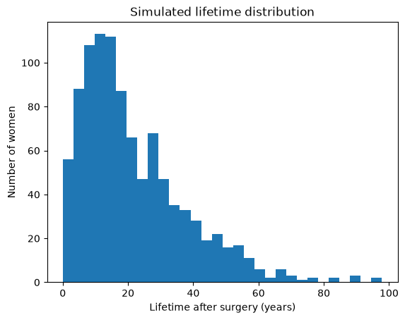

```
Proportion with any recurrence: 0.889
Proportion with local recurrence: 0.705
Proportion local among those with recurrence: 0.7930258717660292
```

### Validation

|  | State | Simulated | Analytical | Difference |
| --- | --- | --- | --- | --- |
| 0 | 1 | 0.597 | 0.599188 | -0.002188 |
| 1 | 2 | 0.162 | 0.154575 | 0.007425 |
| 2 | 3 | 0.108 | 0.116549 | -0.008549 |
| 3 | 4 | 0.031 | 0.028794 | 0.002206 |
| 4 | 5 | 0.102 | 0.100895 | 0.001105 |

# Task 2

### More imports

### Simulated distribution

```
(array([352, 179, 161,  64, 244]), array([0.352, 0.179, 0.161, 0.064, 0.244]))
```

### Analytical distribution

```
(array([359.02626821, 158.95603979, 166.08689731,  67.74149395,
        248.18930075]),
 array([0.35902627, 0.15895604, 0.1660869 , 0.06774149, 0.2481893 ]))
```

### Plot result

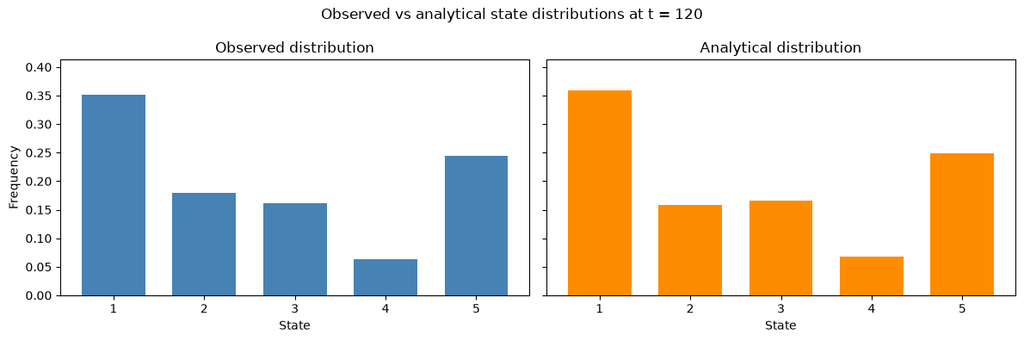

### Comparrison

|  | State | Observed count | Observed proportion | Expected proportion | Expected count |
| --- | --- | --- | --- | --- | --- |
| 0 | 1 | 352 | 0.352 | 0.359026 | 359.026268 |
| 1 | 2 | 179 | 0.179 | 0.158956 | 158.956040 |
| 2 | 3 | 161 | 0.161 | 0.166087 | 166.086897 |
| 3 | 4 | 64 | 0.064 | 0.067741 | 67.741494 |
| 4 | 5 | 244 | 0.244 | 0.248189 | 248.189301 |

### Test

```
Chi-square statistic: 3.0981640968332864
p-value: 0.5415343741426009
```

The null hypothesis is that the simulated states at t = 120 follow the analytical distribution p_120 = p_0 P^120. Since the p-value is not small, we do not reject the null hypothesis. Therefore, the simulated distribution is consistent with the analytical Markov chain distribution.

# Task 3

### Checking means

```
Sample mean lifetime: 259.131
Theoretical mean lifetime: 262.3716153127931
Difference: -3.2406153127931248
```

### Creating survival function to see theoretical vs simulated distrubution of lifetimes

### Creatings bins to evaluate discretely

|  | Lifetime interval | Observed count | Expected count | Observed proportion | Expected probability |
| --- | --- | --- | --- | --- | --- |
| 0 | 0-5 years | 102 | 100.894713 | 0.102 | 0.100895 |
| 1 | 5-10 years | 156 | 147.294588 | 0.156 | 0.147295 |
| 2 | 10-15 years | 169 | 154.140231 | 0.169 | 0.154140 |
| 3 | 15-20 years | 143 | 139.832617 | 0.143 | 0.139833 |
| 4 | 20-30 years | 191 | 209.553027 | 0.191 | 0.209553 |
| 5 | 30-40 years | 106 | 123.123801 | 0.106 | 0.123124 |
| 6 | 40+ years | 133 | 125.161023 | 0.133 | 0.125161 |

```
Chi-square statistic: 6.546026579749234
p-value: 0.3648749650853555
Minimum expected count: 100.8947130188207
```

Since the p-value is not small, we do not reject the hypothesis that the simulated lifetimes follow the theoretical phase-type distribution.

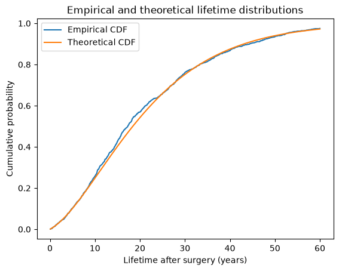

### Looking at PMDF

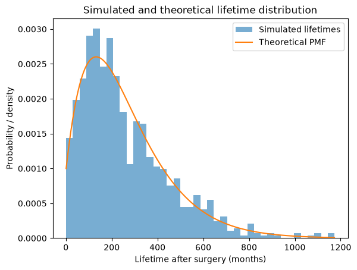

# Task 4

A={T>12 | any recurrence occurs within the first 12 months}.

### Simulation

### Results

|  | Accepted simulations | Total simulated candidates | Acceptance rate | Mean lifetime (months) | Mean lifetime (years) | Std. dev. (months) | Standard error | 95% CI lower (months) | 95% CI upper (months) | Median lifetime (months) |
| --- | --- | --- | --- | --- | --- | --- | --- | --- | --- | --- |
| 0 | 1000 | 11966 | 0.08357 | 171.896 | 14.324667 | 148.581633 | 4.698564 | 162.675813 | 181.116187 | 127.0 |

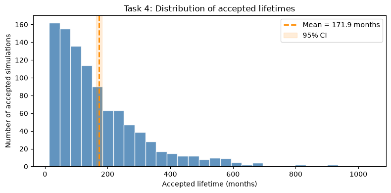

# Task 5

The quantity of interest is θ=P(T≤350)

where T is the lifetime in months after surgery. The crude Monte Carlo estimator is the sample mean of indicators, consistent with the slides’ crude estimator θ^MC=Xˉ. The control variate method uses a correlated variable with known mean and forms Yi=Xi+c(Zi−μZ), where c is chosen to reduce variance.

### Lifetime helper

### Results

For the control variate, we use the theoretical expected lifetime from Task 3:

μT = E(T)=π(I−Ps)^-1 * 1.

```
Theoretical mean lifetime: 262.3716153127931
```

### Estimate control variate

### Compare

|  | Estimator | Mean estimate | Sample variance over 100 runs | Sample standard deviation |
| --- | --- | --- | --- | --- |
| 0 | Crude Monte Carlo | 0.742200 | 0.000767 | 0.027692 |
| 1 | Control variate | 0.739616 | 0.000243 | 0.015574 |

### Variance reduction

```
Estimated c: 0.001972550220799202
Variance crude: 0.0007668282828282838
Variance control variate: 0.00024256047801207213
Variance reduction: 0.6836834485063081
Variance reduction factor: 3.161390054607821
```

### Plot of results

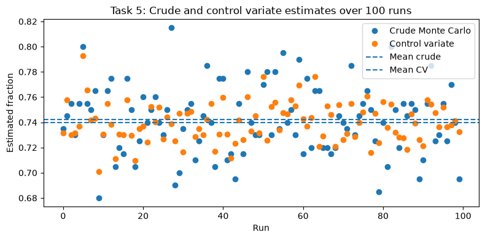

# Task 6

The discrete-time Markov chain model relies on several simplifying assumptions. First, it assumes the Markov property: the future disease progression depends only on the current state and not on how the patient arrived there. For example, two women in the distant metastasis state are treated as having the same future transition probabilities, regardless of when metastasis occurred or whether they previously had local recurrence. Second, the model is time-homogeneous, since the same transition matrix is used at every monthly time step. This means that the probability of recurrence or death is assumed to be the same at all times after surgery, conditional on the current state.

The model also assumes that the disease process can be adequately represented by a finite number of states: no recurrence, local recurrence, distant metastasis, both local and distant recurrence, and death. This is a strong simplification of the real clinical situation. In reality, prognosis may depend on age, tumour size, cancer stage, treatment type, genetic factors, time since surgery, and previous disease history. Furthermore, recurrence and death do not necessarily occur only at monthly time points, so the discrete-time structure is also an approximation.

Some assumptions are reasonable as a first approximation. For example, treating death as an absorbing state is natural, and grouping disease status into a small number of clinically meaningful states makes the model easy to simulate and interpret. However, the Markov and time-homogeneity assumptions are less realistic. Breast cancer recurrence risks often vary over time, and the future risk may depend on the duration already spent in a state.

The model could be made more realistic in several ways. One possibility is to use a time-inhomogeneous Markov chain, where the transition matrix depends on time, (P_t), allowing recurrence and death probabilities to change with time since surgery. Another option is to introduce patient-specific covariates, such as age or tumour stage, so that different groups of women have different transition matrices. A semi-Markov model could also be used, where transition probabilities depend on how long the woman has already spent in the current state. Finally, a continuous-time Markov model could relax the assumption that transitions only occur at monthly time points. These extensions would likely give a more realistic model, but at the cost of more parameters, more data requirements, and increased computational complexity.

# Part 2

# Task 7

Continuous-time Markov chain

```
[-4.33680869e-19 -8.67361738e-19  0.00000000e+00  0.00000000e+00
  0.00000000e+00]
```

We reuse the earlier sample_next_state function. The only difference is that now we first convert the rates in a row of Q into jump probabilities.

We create function to simulate one woman in continuous time. We also track whether distant recurrence has occurred by 30.5 months. Distant recurrence means entering state 3 or state 4.

### Simulation run

### Results

```
(np.float64(264.60725146860983),
 np.float64(191.5708844448746),
 np.float64(222.19314433929907))
```

|  | Mean lifetime (months) | Mean lifetime (years) | 95% CI mean lower (months) | 95% CI mean upper (months) | Std. dev. (months) | 95% CI std. lower (months) | 95% CI std. upper (months) | Median lifetime (months) | Min lifetime (months) | Max lifetime (months) |
| --- | --- | --- | --- | --- | --- | --- | --- | --- | --- | --- |
| 0 | 264.607251 | 22.050604 | 252.71938 | 276.495122 | 191.570884 | 183.527273 | 200.357352 | 222.193144 | 2.551655 | 1204.263199 |

### Proportion with distant recurrence

```
Proportion with distant recurrence by 30.5 months: 0.07
```

### Plot results

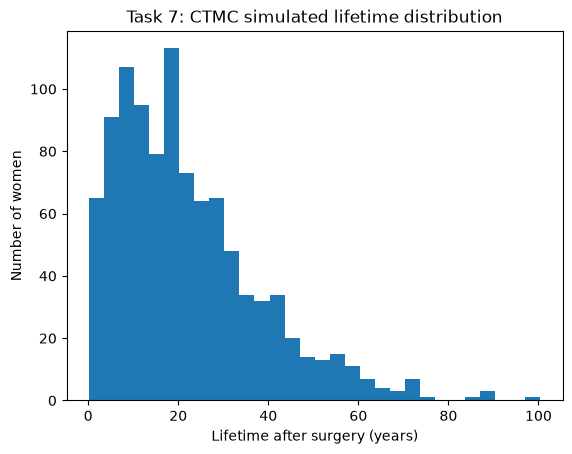

# Task 8

FT(t)=1−p0exp(Qst)1.

Since this is a continuous lifetime distribution, a natural test is the one-sample Kolmogorov--Smirnov test.

The null hypothesis is

H0∼F_T,

meaning that the simulated lifetimes follow the theoretical continuous-time phase-type distribution.

### Define transient matrix Qs, p0 and theoretical cdf

### KS test

```
KS statistic: 0.023529394767537737
p-value: 0.6284090317932944
```

### Plot ECDF against TCDF

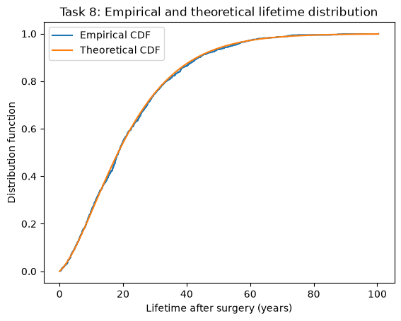

The simulated lifetimes from Task 7 were compared with the theoretical continuous-time phase-type distribution. The theoretical distribution function was computed as:

FT(t)=1−p0exp(Qst)1.

Since the lifetime is continuous, we used a one-sample Kolmogorov--Smirnov test. The null hypothesis was that the simulated lifetimes follow the theoretical phase-type distribution. The empirical distribution function was also plotted against the theoretical distribution function. The two curves were close, and the KS test did not reject the null hypothesis at the 5% level. Thus, the simulated lifetime distribution appears consistent with the theoretical CTMC model.

# Task 9

S(t)=P(T>t)

and with no censoring, the Kaplan--Meier estimate is just the empirical survival function:

S^(t)=#{Ti>t}/N

```
[[-0.00475  0.0025   0.00125  0.       0.001  ]
 [ 0.      -0.007    0.       0.002    0.005  ]
 [ 0.       0.      -0.008    0.003    0.005  ]
 [ 0.       0.       0.      -0.009    0.009  ]
 [ 0.       0.       0.       0.       0.     ]]
True
```

### Simulate

### Kaplan--Meier estimator

### Plot Treatment vs no treatment

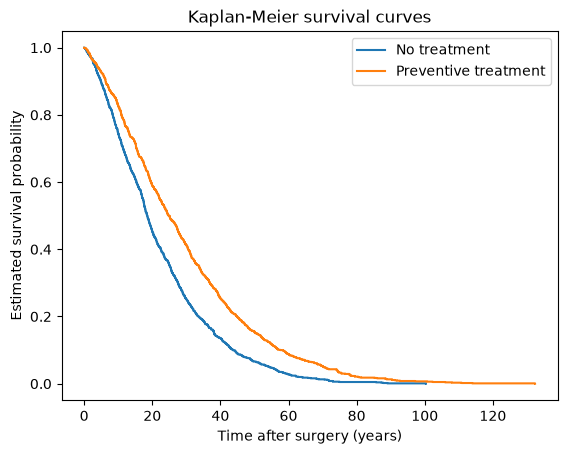

### Numerical summary

|  | Group | Mean lifetime (months) | Mean lifetime (years) | Median lifetime (months) | Survival at 350 months |
| --- | --- | --- | --- | --- | --- |
| 0 | No treatment | 264.607251 | 22.050604 | 222.193144 | 0.265 |
| 1 | Preventive treatment | 350.128663 | 29.177389 | 299.300628 | 0.428 |

The Kaplan--Meier survival curve for the preventive treatment group lies above the curve for the untreated group for most of the time interval. This indicates that the treatment appears to improve survival. The effect is also visible in the simulated mean and median lifetimes, which are larger for the treated group. Therefore, based on the visual comparison, the preventive treatment appears to have a positive effect on survival.

# Part 3

# Task 12

We simulate partial observations rather than fully observed trajectories. Women are observed every 48 months, and each observed time series should have the form

Y(i)=(X(0),X(48),X(96),…),

continuing until the last observed value is death, state 5.

Interpretation is: if a woman dies between two screenings, then the next scheduled observation records state 5. So the observed vectors always correspond to times

0,48,96,144,…

until the first observation time where the woman is dead.

### Simulation function

### Simulation

### Inspection

```
Woman 1:
Times:  [  0.  48.  96. 144.]
States: [1 1 1 5]

Woman 2:
Times:  [ 0. 48.]
States: [1 5]

Woman 3:
Times:  [  0.  48.  96. 144. 192. 240.]
States: [1 2 2 2 4 5]

Woman 4:
Times:  [  0.  48.  96. 144.]
States: [1 1 2 5]

Woman 5:
Times:  [ 0. 48. 96.]
States: [1 4 5]
```

```
All start in state 1: True
All end in state 5: True
```

### Results

|  | Number of women | Observation interval (months) | Mean number of observations | Median number of observations | Minimum number of observations | Maximum number of observations |
| --- | --- | --- | --- | --- | --- | --- |
| 0 | 1000 | 48 | 7.019 | 6.0 | 2 | 27 |

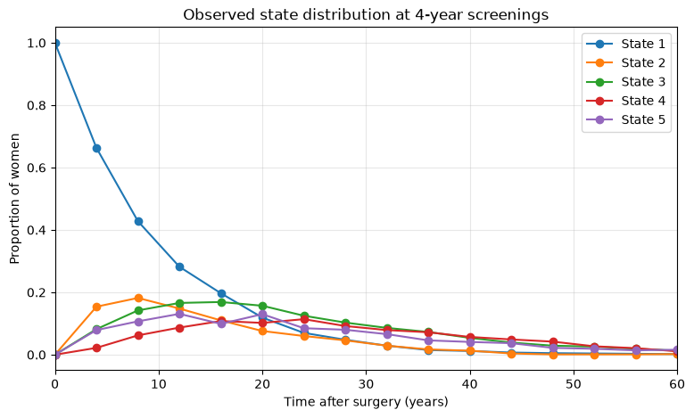

# Task 13

The idea is to treat the observed series from Task 12 as incomplete data. In each iteration, we simulate a possible complete CTMC path between each pair of observations, conditional on matching the next observed state. Then we estimate

qij= Nij / Si,

### Allowed transition structure

### Initial guess

```
array([[-0.008,  0.004,  0.002,  0.   ,  0.002],
       [ 0.   , -0.01 ,  0.003,  0.003,  0.004],
       [ 0.   ,  0.   , -0.007,  0.003,  0.004],
       [ 0.   ,  0.   ,  0.   , -0.007,  0.007],
       [ 0.   ,  0.   ,  0.   ,  0.   ,  0.   ]])
```

### Simulate one CTMC interval

### Simulate interval conditional on next observation

### Reconstruct trajectories for states once

### Update the guess (Q)

Using qij= Nij / Si,

### Run MC

```
Iteration  1: max difference = 0.00309, average attempts per interval = 4.47
Iteration  2: max difference = 0.00072, average attempts per interval = 4.02
Convergence criterion reached.
```

### Compare estimates

|  | To 1 | To 2 | To 3 | To 4 | To 5 |
| --- | --- | --- | --- | --- | --- |
| From 1 | -0.008859 | 0.005112 | 0.002357 | 0.000000 | 0.001391 |
| From 2 | 0.000000 | -0.013808 | 0.004882 | 0.004236 | 0.004690 |
| From 3 | 0.000000 | 0.000000 | -0.007457 | 0.003316 | 0.004141 |
| From 4 | 0.000000 | 0.000000 | 0.000000 | -0.008260 | 0.008260 |
| From 5 | 0.000000 | 0.000000 | 0.000000 | 0.000000 | 0.000000 |

|  | Transition | True rate | Estimated rate | Difference |
| --- | --- | --- | --- | --- |
| 0 | 1 -> 2 | 0.0050 | 0.005112 | 0.000112 |
| 1 | 1 -> 3 | 0.0025 | 0.002357 | -0.000143 |
| 2 | 1 -> 5 | 0.0010 | 0.001391 | 0.000391 |
| 3 | 2 -> 3 | 0.0050 | 0.004882 | -0.000118 |
| 4 | 2 -> 4 | 0.0040 | 0.004236 | 0.000236 |
| 5 | 2 -> 5 | 0.0050 | 0.004690 | -0.000310 |
| 6 | 3 -> 4 | 0.0030 | 0.003316 | 0.000316 |
| 7 | 3 -> 5 | 0.0050 | 0.004141 | -0.000859 |
| 8 | 4 -> 5 | 0.0090 | 0.008260 | -0.000740 |

### Plot

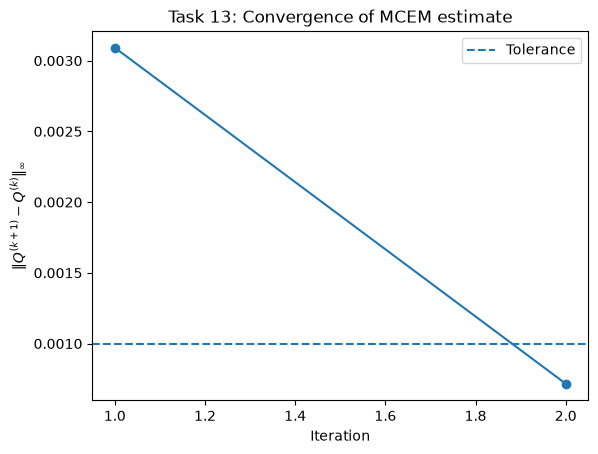

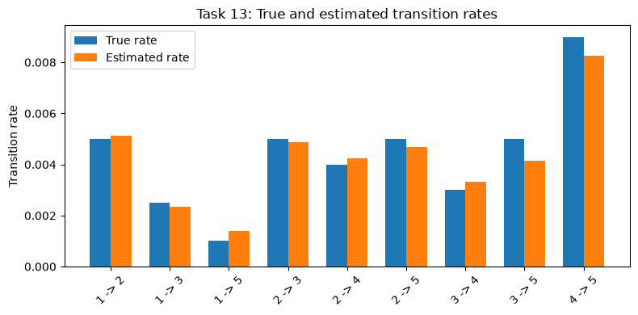

### Task 13: Monte Carlo EM estimation from partially observed CTMC data

In Task 13, only the partially observed time series from Task 12 was assumed to be available. Therefore, the complete transition counts $N_{ij}$ and sojourn times $S_i$ were unknown. To approximate these quantities, we used the proposed Monte Carlo EM approach.

Starting from an initial guess $Q^{(0)}$, we simulated complete CTMC paths between each pair of consecutive observations. Paths that did not match the next observed state were rejected. From the accepted reconstructed paths, we computed the total jump counts $N_{ij}$ and the total sojourn times $S_i$. The transition rates were then updated by

$$ q_{ij}^{(k+1)} = \frac{N_{ij}}{S_i}, \qquad i \neq j, $$

with diagonal entries chosen such that each row of $Q$ sums to zero:

$$ q_{ii}^{(k+1)} = -\sum_{j \neq i} q_{ij}^{(k+1)}. $$

This procedure was repeated until convergence, defined by

$$ \left\| Q^{(k+1)} - Q^{(k)} \right\|_{\infty} < 10^{-3}. $$

The estimated transition-rate matrix was close to the original matrix used to simulate the data. However, some Monte Carlo error remained because only one reconstructed path was simulated for each observed interval in each iteration. Increasing the number of reconstructed paths per interval would reduce this Monte Carlo noise, but it would also increase the computational cost.